# Pembangkitan ARMA

# Proses MA(2)

## Bangkitkan Data

### Manual

#### White Noise

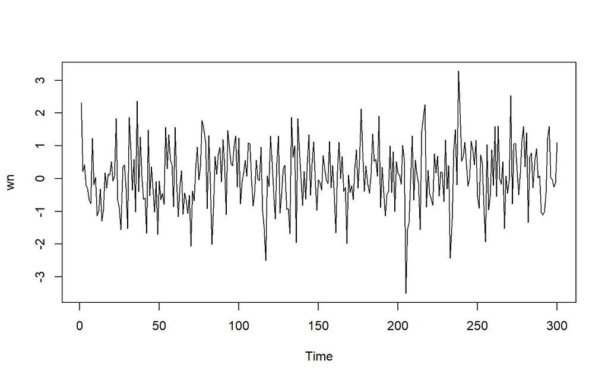

```r
set.seed(066)
wn <- rnorm(300)
ts.plot(wn)
```

#### Plot ACF

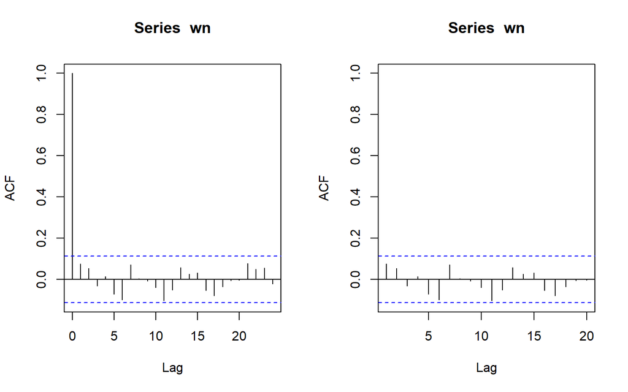

```r
par(mfrow = c(1, 2))
acf(wn)
acf(wn, xlim = c(1, 20))
```

#### Bangkitkan Data

```r
ma <- wn[1:2]
for(i in 3:300){
  ma[i] <- wn[i] + 0.4 * wn[i - 1] + 0.6 * wn[i - 2]}
ma
```

```
##   [1]  2.32397466  0.21697710  1.89936832  0.10647051 -0.14031992 -0.88838918
##   [7] -1.20474967  0.53636127 -0.14087570  0.69674681 -1.23089202 -1.42446155
##  [13] -1.38889449 -2.01428064 -1.65119973 -0.97227904 -0.78590210  0.12416956
##  [19] -0.01781511  0.63757632  0.20118834  0.34869390  1.81614479  0.12115337
##  [25] -0.05680679 -2.30804838 -0.81049959 -0.37649556  0.08272673 -1.39088515
##  [31]  1.08384217  0.73071908  1.12719425  0.98326539 -0.99292282  2.31329543
##  [37] -0.06332066  2.53086388  0.34718093  0.16778374 -0.80177970 -2.28616312
##  [43]  0.46255229 -0.93202387  1.04258653 -0.46142263 -0.92131590 -0.66795448
##  [49] -2.34651884 -0.80478546 -1.69258363 -0.74628371 -1.35202542  0.99221352
##  [55]  0.45488643  2.40906681  1.29757320  1.46376243 -0.34080771  1.48491837
##  [61] -0.04002126 -0.28090886 -0.81255426 -0.56075707 -1.14732392 -0.72293619
##  [67] -1.48710590 -1.59071729 -1.33347913 -2.91526823 -1.51403426 -2.07215857
##  [73] -0.17693720  0.68325333  0.54637641  0.93069600  1.90848827  2.49126017
##  [79]  2.78814803  0.44845297  1.60109316 -0.18476926 -1.27830446 -1.77548666
##  [85] -0.87851480 -0.13046842  1.19654629  1.32281580  0.72361676  1.72057363
```

[output cut: 35 more lines]

### Fungsi `arima.sim()`

```r
ma2 <- arima.sim(
  list(order = c(0, 0, 2), ma = c(0.4, 0.6)),
  n = 300)
ma2
```

```
## Time Series:
## Start = 1
## End = 300
## Frequency = 1
##   [1] -1.978120310 -1.568860995 -1.772600649 -0.943822851  0.130140555
##   [6]  1.031344800  3.311469775  1.469510176  0.353874766 -0.323040709
##  [11] -2.028481991 -0.802958359 -0.315917954  1.592016029  0.766453873
##  [16]  0.900566699  1.134622477  0.689533581  0.089374286  0.376000449
##  [21] -0.766020516  0.833069320  0.598087081 -1.007606420 -0.216883381
##  [26] -0.823488345 -0.774828813  0.449303880  0.698426805  1.496211550
##  [31]  1.733351111  1.230127283  1.182908283  1.695665358  0.710681475
##  [36]  2.347790215  1.586927924  2.383354230  1.255972903  1.513198940
##  [41]  0.361834408  0.278984376 -1.147270818 -0.541955224 -0.731859924
##  [46] -2.183621589 -2.312613534 -0.752720041  0.083369582  1.474300338
##  [51]  0.976712798  0.116297090  0.018372020  0.577783003 -0.326748443
```

[output cut: 49 more lines]

## Plot

### Time Series

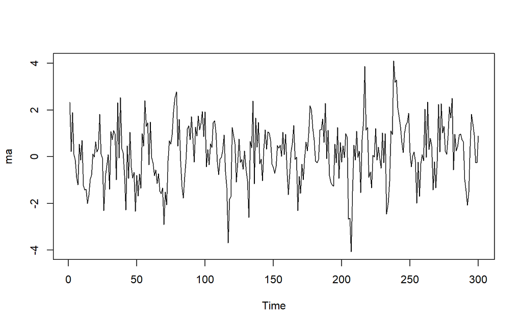

```r
ts.plot(ma)
```

- Data berfluktuasi di sekitar rata-rata yang relatif konstan (sekitar 0).
- Tidak terlihat adanya tren naik atau turun.
- Varians data juga relatif konstan sepanjang waktu.

### ACF

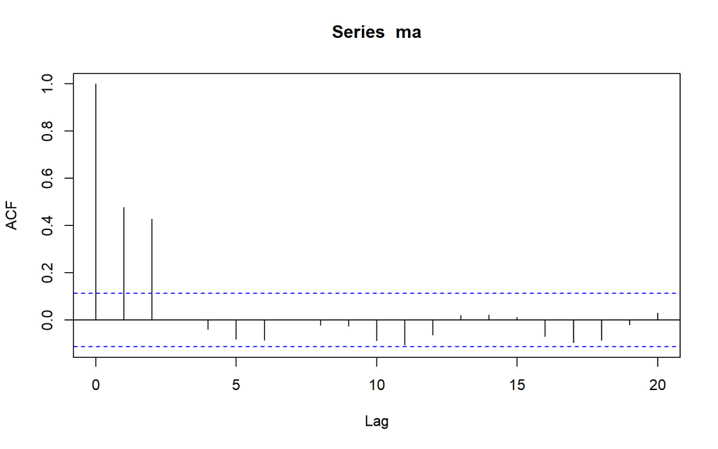

```r
acf(ma,lag.max = 20)
```

- Lag 1 memiliki autokorelasi sekitar 0,47 dan signifikan.
- Lag 2 memiliki autokorelasi sekitar 0,43 dan signifikan.
- Mulai dari lag 3, sebagian besar nilai ACF berada di dalam batas signifikansi.
- ACF terputus setelah Lag 2

### PACF

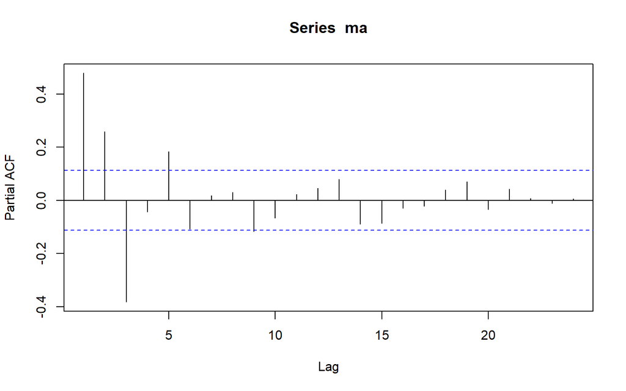

```r
pacf(ma)
```

Pada PACF, tidak terlihat pola cut off yang jelas. Nilai PACF cenderung menurun/berfluktuasi (tailing off) setelah beberapa lag.

### EACF

```r
TSA::eacf(ma)
```

```
## AR/MA
##   0 1 2 3 4 5 6 7 8 9 10 11 12 13
## 0 x x o o o o o o o o o  o  o  o
## 1 x x o o o o o o o o o  o  o  o
## 2 x x x x o o o o o o o  o  o  o
## 3 o x x x o o o o o o o  o  o  o
## 4 x x o o x x o o o o o  o  o  o
## 5 x x o o o x x o o o o  o  o  o
## 6 x x o o o o o x o o o  o  o  o
## 7 x o o x o o o o x o o  o  o  o
```

Pada tabel EACF terlihat pola `o` yang mulai membentuk area segitiga setelah kandidat AR = 0 dan MA = 2.

### Apakah Data Stasioner?

Berdasarkan plot deret waktu, ACF, PACF, dan EACF, data dapat dikatakan **stasioner**. Hal ini ditunjukkan oleh data yang berfluktuasi di sekitar rata-rata yang relatif konstan tanpa tren, serta pola ACF yang terputus setelah lag ke-2 dan PACF yang cenderung tailing off. Hasil EACF juga mengindikasikan model MA(2), sesuai dengan model pembangkitan data.

## Scatter Plot Antar Lag

### Korelasi antara $Y_t$ dengan $Y_{t−1}$

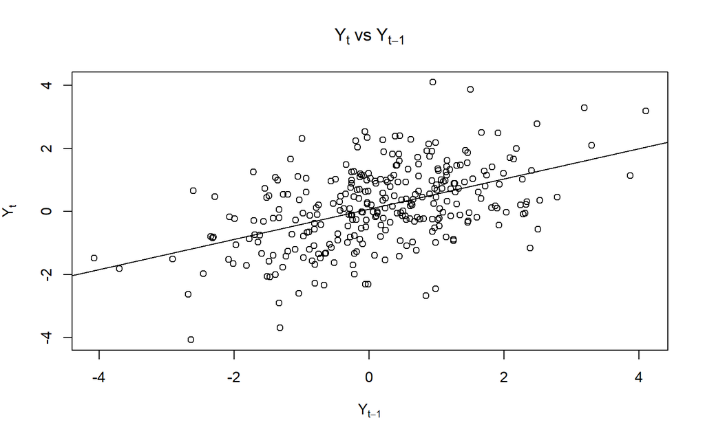

```r
Y <- as.numeric(ma)

plot(
  Y[-length(Y)],
  Y[-1],
  main = expression(Y[t]~vs~Y[t-1]),
  xlab = expression(Y[t-1]),
  ylab = expression(Y[t])
)

abline(lm(Y[-1] ~ Y[-length(Y)]))
```

### Korelasi antara $Y_t$ dengan $Y_{t−2}$

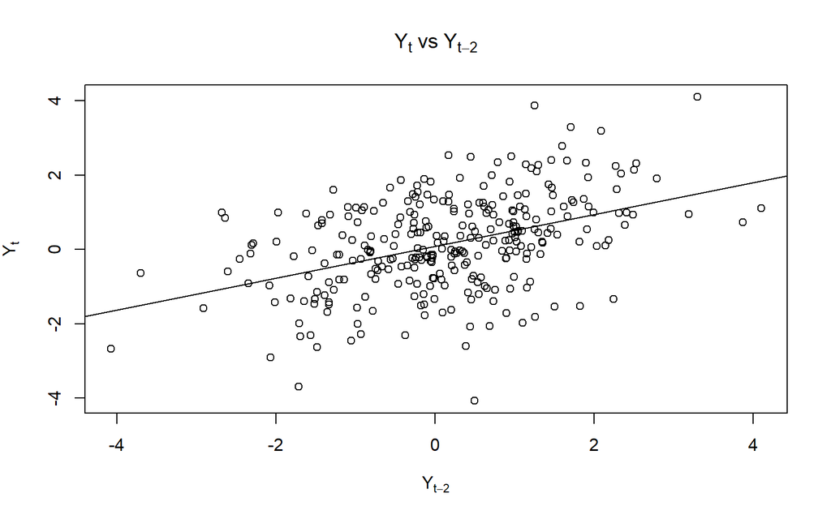

```r
plot(
  Y[-c(1,2)],
  Y[-c(length(Y)-1, length(Y))],
  main = expression(Y[t]~vs~Y[t-2]),
  xlab = expression(Y[t-2]),
  ylab = expression(Y[t])
)

abline(
  lm(Y[-c(1,2)] ~ Y[-c(length(Y)-1, length(Y))])
)
```

### Korelasi antara $Y_t$ dengan $Y_{t−3}$

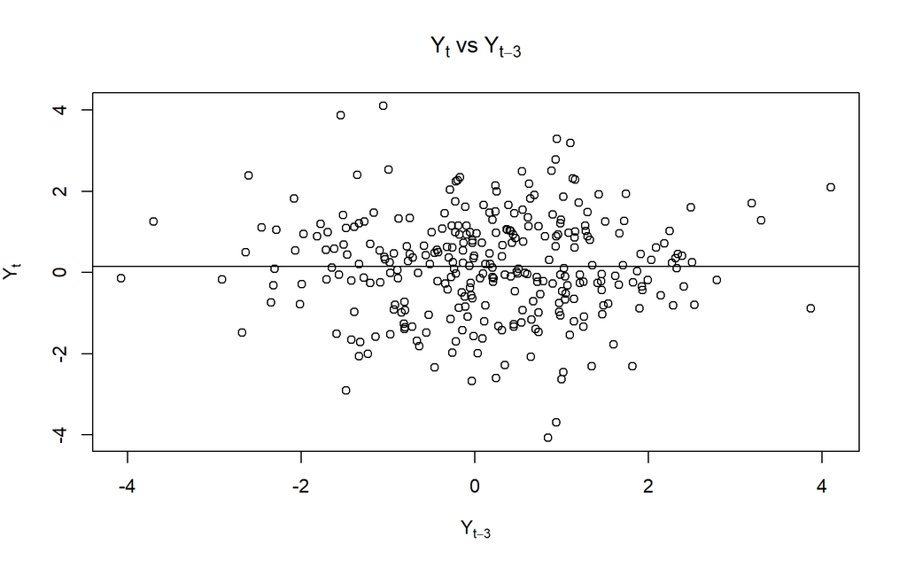

```r
plot(
  Y[-c(length(Y)-2, length(Y)-1, length(Y))],
  Y[-c(1,2,3)],
  main = expression(Y[t]~vs~Y[t-3]),
  xlab = expression(Y[t-3]),
  ylab = expression(Y[t])
)

abline(
  lm(Y[-c(1,2,3)] ~ Y[-c(length(Y)-2, length(Y)-1, length(Y))])
)
```

## Autokorelasi

```r
# Autokorelasi empiris
cor_lag1 <- cor(
  ma[-1],
  ma[-length(ma)]
)

cor_lag2 <- cor(
  ma[-c(1,2)],
  ma[-c(length(ma)-1, length(ma))]
)

cor_lag3 <- cor(
  ma[-c(1,2,3)],
  ma[-c(length(ma)-2,
             length(ma)-1,
             length(ma))]
)

# Autokorelasi teoritis
teoritis <- ARMAacf(
  ma = c(0.4, 0.6),
  lag.max = 3
)

hasil_acf <- data.frame(
  Lag = 1:3,
  Empiris = c(cor_lag1, cor_lag2, cor_lag3),
  Teoritis = teoritis[2:4]
)

hasil_acf
```

```
##   Lag      Empiris  Teoritis
## 1   1 0.4810772246 0.4210526
## 2   2 0.4311021808 0.3947368
## 3   3 0.0006875914 0.0000000
```

Autokorelasi teoritis pada lag 1 sebesar 0.4211 dan lag 2 sebesar 0.3947, sedangkan nilai empirisnya masing-masing sebesar 0.4811 dan 0.4311. Nilai empiris tersebut relatif mendekati nilai teoritis. Pada lag 3, autokorelasi empiris sebesar 0.0007, yang sangat dekat dengan nilai teoritis 0. Hal ini menunjukkan bahwa autokorelasi pada proses MA(2) terputus setelah lag ke-2, sehingga hasil empiris sesuai dengan karakteristik teoritis proses MA(2).

# Proses AR(2)

## Bangkitkan Data

### Manual

```r
n <- 300
wn <- rnorm(n)
ar <- c(wn[1:2], rep(0, n-2))
for (i in 3:n) {
  ar[i] <- wn[i] + 0.5 * ar[i-1] + 0.2 * ar[i-2]
}

ar
```

```
##   [1] -0.01513104  1.94898194  1.35235748  1.55488341  0.45969121 -0.23171518
##   [7] -0.56408181 -0.44216114 -1.63383859 -0.94254937  0.13022688 -1.84924252
##  [13] -1.16834932 -0.70577943 -0.30928056  1.13765188 -0.08625842  0.51787851
##  [19]  2.32392954  1.42846276  0.90013040  1.25902976  0.64660710 -0.44985504
##  [25] -0.28792496 -0.11322620 -0.58552796  0.76225507  0.19183324  0.29497876
##  [31] -0.05773442 -0.13724316  0.16445582 -1.37708556 -1.93708297 -2.65514795
##  [37] -2.38175284 -0.32677952 -0.78758056 -0.34863626  0.36593584 -0.35043429
##  [43] -1.05405168 -0.06605568  1.35567213 -1.59746277 -0.05045251 -0.49654360
##  [49] -0.52053857  0.24908526 -0.18787438  0.65215000  1.57213213  0.37866003
##  [55]  1.11603905  0.18458978  1.31596348 -0.04530430  0.11017315  0.62210723
##  [61]  0.64416324  0.41764640  0.12424181  0.94637014  1.27190850  3.50556741
##  [67]  1.45372618  3.08300873  0.94568570  1.02633793 -0.62330225  0.33388104
##  [73]  1.31645803 -0.41184864 -0.28564475 -0.90563789 -0.78878736 -0.75280064
##  [79] -0.27749675 -0.27229919 -1.05702466 -1.38939418 -0.63463378 -1.50731217
##  [85] -0.48619663 -0.38140477 -0.26139198  0.95653142 -0.66262108 -0.46124972
```

[output cut: 35 more lines]

### Fungsi `arima.sim()`

```r
ar2 <- arima.sim(
  list(order = c(2, 0, 0), ar = c(0.5, 0.2)),
  n = 300)
ar2
```

```
## Time Series:
## Start = 1
## End = 300
## Frequency = 1
##   [1]  2.623925668  0.203031962  0.076180520  2.070994724  3.520367612
##   [6]  1.378997053 -0.464132347  1.435955437  0.600642454 -0.842657323
##  [11] -1.517575530 -2.023581512 -1.802251845 -1.263987264 -0.918267385
##  [16] -0.473016427  0.613008273 -0.895235552 -0.747019769 -0.303651304
##  [21] -0.430232123 -0.770500398  0.901374313 -0.033425880  0.238396825
##  [26] -0.716210681 -1.638281976 -0.691993259  0.057595606  1.227315228
##  [31]  0.370673421  1.699688674 -0.269031353  1.477438532  1.509954435
##  [36]  0.431912023 -0.243941296  2.127851075  0.812173276  2.007102379
##  [41]  0.359306543  0.441833455 -0.704015522 -1.861048555 -1.312542921
##  [46] -2.524746136  0.920756634 -0.747624217  0.298106578  0.379057385
##  [51]  0.074548507 -0.435312617 -0.936527421 -1.457061913 -0.137712442
```

[output cut: 49 more lines]

## Plot

### Time Series

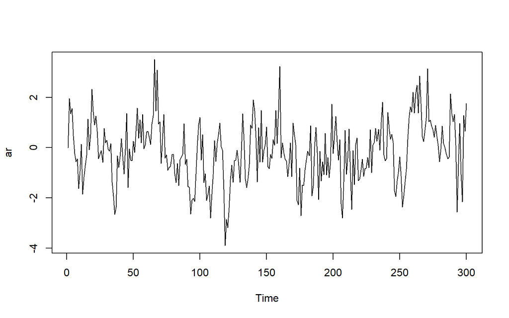

```r
ts.plot(ar)
```

- Data berfluktuasi di sekitar rata-rata yang relatif konstan (sekitar nol).
- Tidak terdapat pola tren naik atau turun yang jelas.
- Varians data relatif tetap sepanjang waktu.

### ACF

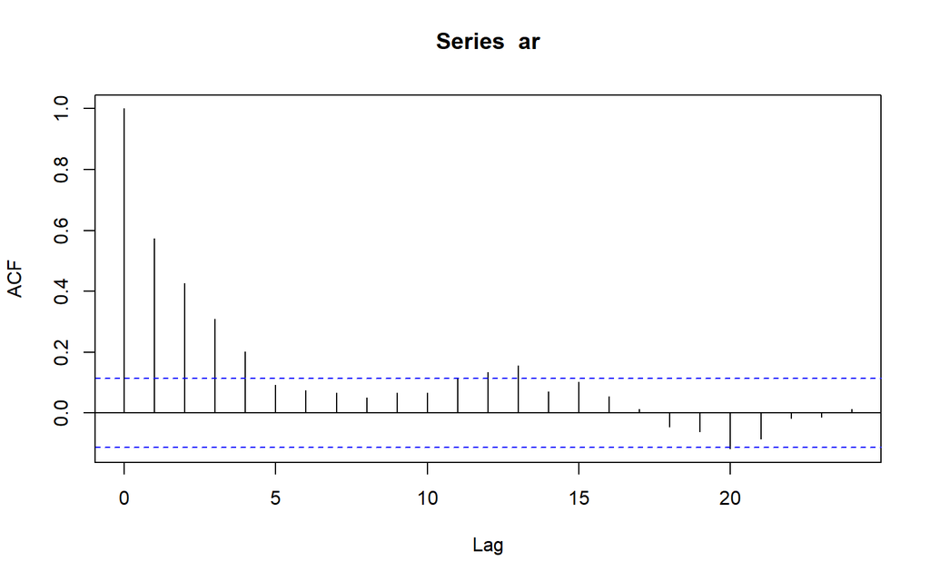

```r
acf(ar)
```

- Nilai autokorelasi pada lag awal cukup besar.
- Autokorelasi kemudian menurun secara bertahap (tailing off) menuju nol.

### PACF

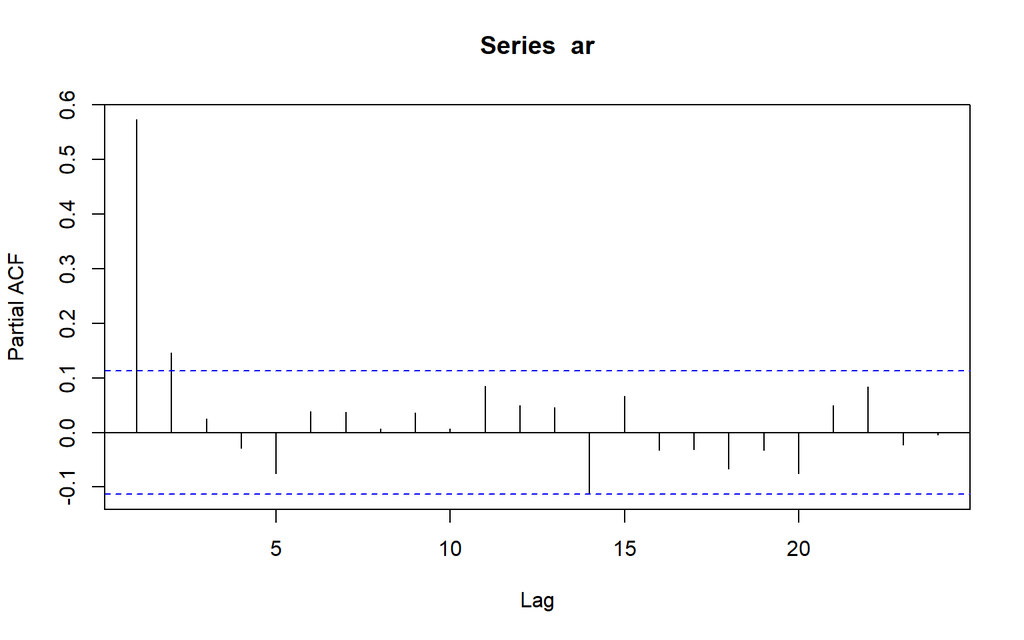

```r
pacf(ar)
```

- Lag 1 dan lag 2 signifikan.
- Setelah lag ke-2, sebagian besar nilai PACF berada dalam batas signifikansi.
- PACF mengalami cut off pada lag ke-2.

### EACF

```r
TSA::eacf(ar)
```

```
## AR/MA
##   0 1 2 3 4 5 6 7 8 9 10 11 12 13
## 0 x x x x o o o o o o o  x  x  o
## 1 x o o o o o o o o o o  o  x  o
## 2 x o o o o o o o o o o  o  o  o
## 3 x x o o o o o o o o o  o  o  o
## 4 x x x o o o o o o o o  o  o  o
## 5 x x x o o o o o o o o  o  o  o
## 6 x x x x x o o o o o o  o  o  o
## 7 o x x x o x o o o o o  o  o  o
```

## Scatter Plot Antar Lag

### Korelasi antara $Y_t$ dengan $Y_{t−1}$

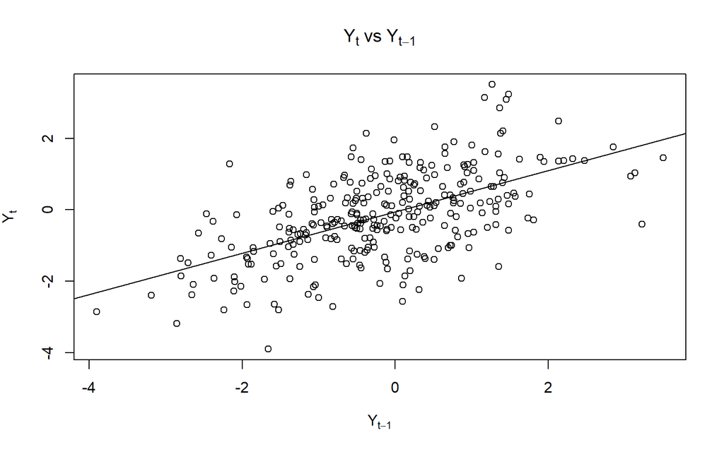

```r
Y <- as.numeric(ar)

plot(
  Y[-length(Y)],
  Y[-1],
  main = expression(Y[t]~vs~Y[t-1]),
  xlab = expression(Y[t-1]),
  ylab = expression(Y[t])
)

abline(
  lm(Y[-1] ~ Y[-length(Y)])
)
```

### Korelasi antara $Y_t$ dengan $Y_{t−2}$

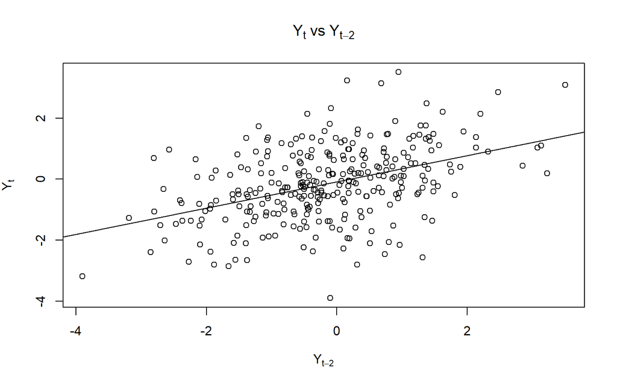

```r
plot(
  Y[-c(length(Y)-1, length(Y))],
  Y[-c(1,2)],
  main = expression(Y[t]~vs~Y[t-2]),
  xlab = expression(Y[t-2]),
  ylab = expression(Y[t])
)

abline(
  lm(Y[-c(1,2)] ~ Y[-c(length(Y)-1, length(Y))])
)
```

### Korelasi antara $Y_t$ dengan $Y_{t−3}$

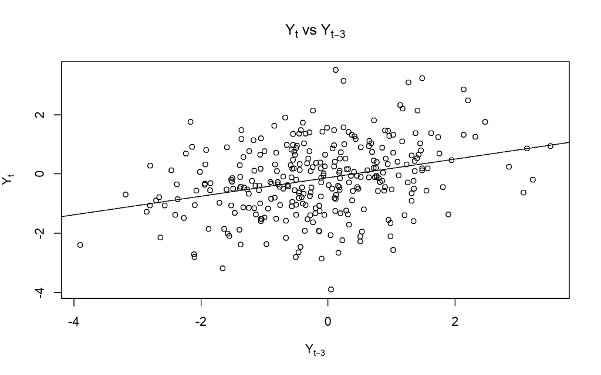

```r
plot(
  Y[-c(length(Y)-2, length(Y)-1, length(Y))],
  Y[-c(1,2,3)],
  main = expression(Y[t]~vs~Y[t-3]),
  xlab = expression(Y[t-3]),
  ylab = expression(Y[t])
)

abline(
  lm(Y[-c(1,2,3)] ~
       Y[-c(length(Y)-2, length(Y)-1, length(Y))])
)
```

## Autokorelasi

```r
# Autokorelasi empiris
cor_lag1 <- cor(
  ar[-1],
  ar[-length(ar)]
)
cor_lag2 <- cor(
  ar[-c(1,2)],
  ar[-c(length(ar)-1, length(ar))]
)

cor_lag3 <- cor(
  ar[-c(1,2,3)],
  ar[-c(length(ar)-2,
             length(ar)-1,
             length(ar))]
)

# Autokorelasi teoritis AR(2)
teoritis <- ARMAacf(
  ar = c(0.5, 0.2),
  lag.max = 3
)

# Tabel perbandingan
hasil_acf <- data.frame(
  Lag = 1:3,
  Empiris = c(cor_lag1, cor_lag2, cor_lag3),
  Teoritis = teoritis[2:4]
)

hasil_acf
```

```
##   Lag   Empiris Teoritis
## 1   1 0.5753926  0.62500
## 2   2 0.4306571  0.51250
## 3   3 0.3133918  0.38125
```

Nilai autokorelasi empiris pada lag 1, 2, dan 3 relatif mendekati nilai autokorelasi teoritis. Perbedaan yang terjadi disebabkan oleh variasi sampel. Pola autokorelasi yang menurun secara bertahap sesuai dengan karakteristik proses AR(2).

# Proses ARMA(2,2)

## Bangkitkan Data

### Manual

```r
n <- 300

phi1 <- 0.5
phi2 <- 0.2

theta1 <- 0.4
theta2 <- 0.6

epsilon <- rnorm(n)

arma22 <- numeric(n)

arma22[1] <- epsilon[1]

arma22[2] <-
  phi1 * arma22[1] +
  epsilon[2] +
  theta1 * epsilon[1]

for (t in 3:n) {
  arma22[t] <-
    phi1 * arma22[t-1] +
    phi2 * arma22[t-2] +
    epsilon[t] +
    theta1 * epsilon[t-1] +
    theta2 * epsilon[t-2]
}

arma22 <- ts(arma22)
arma22
```

```
## Time Series:
## Start = 1
## End = 300
## Frequency = 1
##   [1]  0.647869800  0.743658621  0.612317675  0.683949737 -0.320216585
##   [6]  2.720648045  0.889995460  1.981022402  1.044623536  2.707390676
##  [11]  3.477729806  4.398329097  3.458064143  3.889899911  4.176893626
##  [16]  4.181055612  1.705179753  0.802765809 -0.263296958  0.004322609
##  [21] -1.043897574 -0.338684462 -1.177105578 -0.185503445  0.222333399
##  [26]  0.200715061  2.814937361  2.015609973  4.338235940  2.556037824
##  [31]  0.325351453 -0.258137780 -0.574795530  0.647235171  1.204777215
##  [36]  2.343492827  2.060451264  1.637744348 -0.230590423  0.075156116
##  [41] -0.179173550  0.753467285 -0.636899833 -0.158906595 -1.326899552
##  [46]  1.715416743  0.063011993  1.616476998  0.993166951  0.278591537
##  [51]  0.517200947 -0.396147554  0.519665196  0.041390502 -0.363067453
```

[output cut: 49 more lines]

### Fungsi `arima.sim()`

```r
arimaf <- arima.sim(
  model = list(
    ar = c(phi1, phi2),
    ma = c(theta1, theta2)
  ),
  n = 300
)
arimaf
```

```
## Time Series:
## Start = 1
## End = 300
## Frequency = 1
##   [1] -0.490206557 -3.113088103 -4.204513055 -4.188635086 -2.476939985
##   [6] -1.398864042  1.114688749 -0.902421849  0.527480480 -1.611608043
##  [11] -1.428845599 -2.094440816 -1.811703972 -0.225085276  0.601663878
##  [16] -0.189559303 -0.569354967 -1.336270078 -0.230306309 -0.079619032
##  [21]  0.491012490  1.311513545  1.984961075  2.451018570  2.234050439
##  [26]  3.068204837  3.255806856  3.112987210  3.288068180  3.017062636
##  [31]  1.497019956  0.742417447  0.123642508  0.155207395  0.708418083
##  [36] -0.452671967 -0.606180582  0.008457584 -0.401165707  1.576715327
##  [41]  0.242116791  0.869821222  0.730858708  0.762328043  0.743791347
##  [46] -0.897428214 -1.074865290 -0.438744329 -0.026984197  2.057541664
##  [51]  0.966798092  3.510588258  2.484397961  3.303633129  1.490536910
```

[output cut: 49 more lines]

## Plot

### Time Series

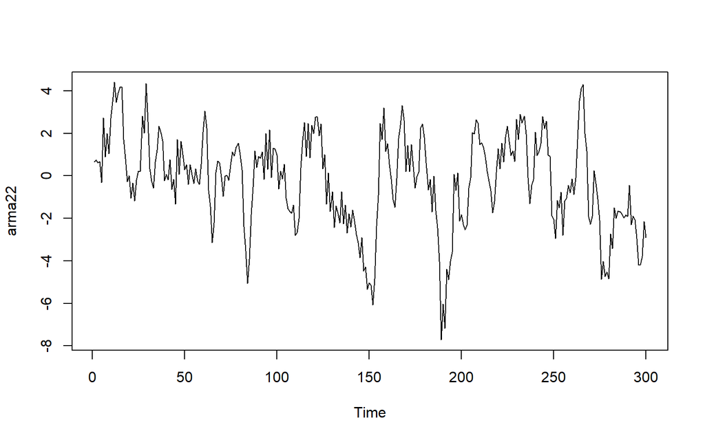

```r
ts.plot(arma22)
```

- Data berfluktuasi di sekitar nilai tengah yang relatif konstan.
- Tidak terlihat adanya tren naik/turun.
- Varians relatif stabil sepanjang waktu.

### ACF

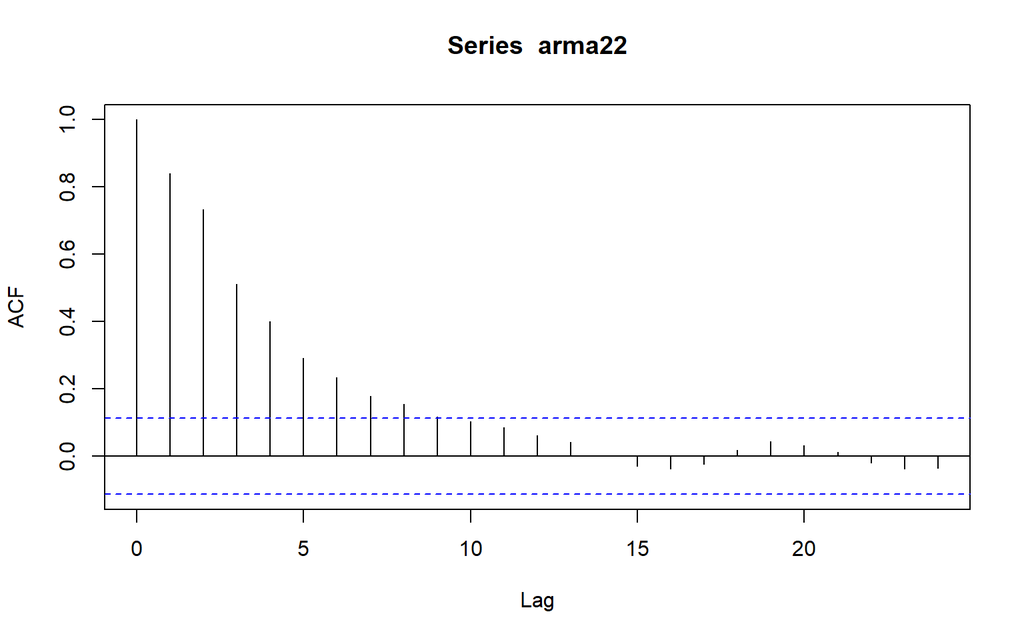

```r
acf(arma22)
```

- ACF menurun secara bertahap (tailing off) menuju nol.
- Tidak menunjukkan pola yang bertahan sangat lama atau mendekati 1.

### PACF

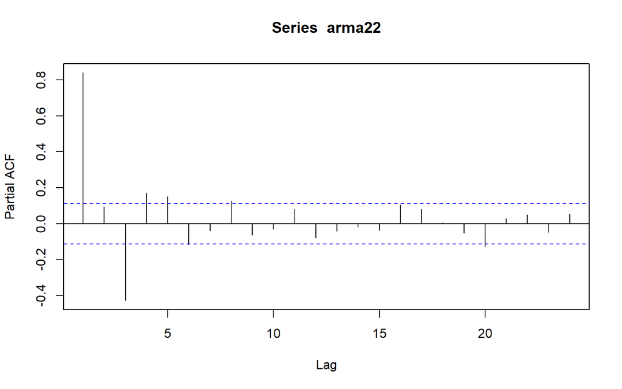

```r
pacf(arma22)
```

- Terdapat beberapa puncak yang signifikan pada lag awal, kemudian sebagian besar berada di dalam batas.
- Pola seperti ini masih sesuai dengan proses ARMA, di mana ACF dan PACF umumnya sama-sama tailing off.

### EACF

```r
TSA::eacf(arma22)
```

```
## AR/MA
##   0 1 2 3 4 5 6 7 8 9 10 11 12 13
## 0 x x x x x x x x x o o  o  o  o
## 1 o x x o o o o o o o o  o  o  o
## 2 x x o o o o o o o o o  o  o  o
## 3 x x o x o o o o o o o  o  o  o
## 4 x x o x o o o o o o o  o  o  o
## 5 x x o x x o o o o o o  o  o  o
## 6 x x o x o o o o o o o  o  o  o
## 7 x x o x o o o o o o o  o  o  o
```

- Polanya menunjukkan kandidat model dengan komponen AR dan MA pada lag rendah, yang konsisten dengan ARMA(2,2).
- Tidak menunjukkan indikasi kuat adanya nonstasioneritas.

### Apakah Data Stasioner?

Berdasarkan plot deret waktu, ACF, PACF, dan EACF, data dapat dikatakan **stasioner** karena tidak menunjukkan tren, memiliki varians yang relatif konstan, serta ACF dan PACF cenderung menurun menuju nol.

## Scatter Antar Lag

### Korelasi antara $Y_t$ dengan $Y_{t−1}$

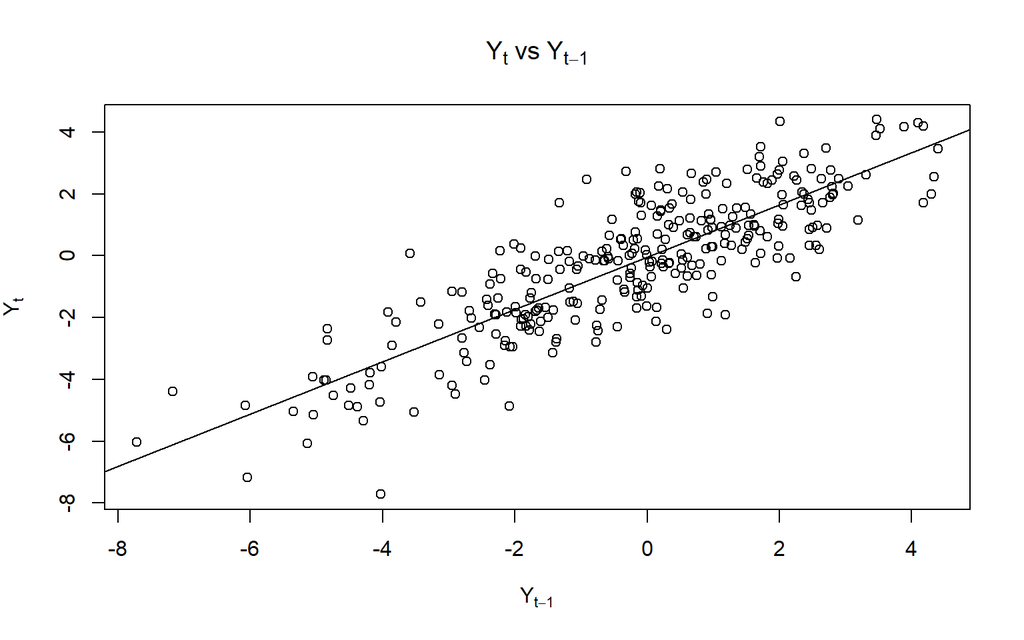

```r
Y <- as.numeric(arma22)

plot(
  Y[-length(Y)],
  Y[-1],
  main = expression(Y[t]~vs~Y[t-1]),
  xlab = expression(Y[t-1]),
  ylab = expression(Y[t])
)

abline(
  lm(Y[-1] ~ Y[-length(Y)])
)
```

### Korelasi antara $Y_t$ dengan $Y_{t−2}$

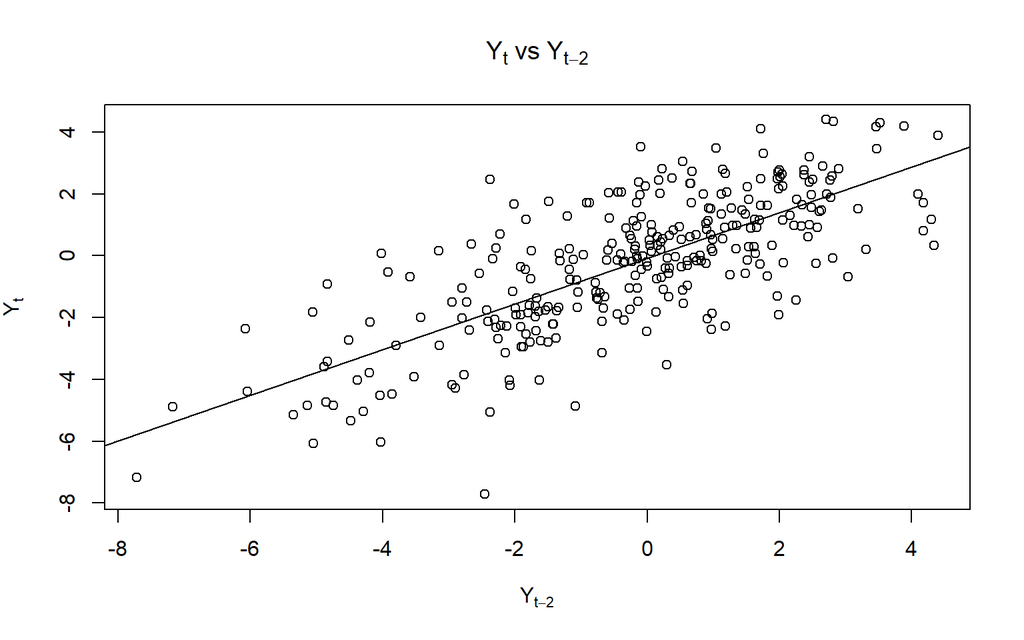

```r
plot(
  Y[-c(length(Y)-1, length(Y))],
  Y[-c(1,2)],
  main = expression(Y[t]~vs~Y[t-2]),
  xlab = expression(Y[t-2]),
  ylab = expression(Y[t])
)

abline(
  lm(
    Y[-c(1,2)] ~
      Y[-c(length(Y)-1, length(Y))]
  )
)
```

### Korelasi antara $Y_t$ dengan $Y_{t−3}$

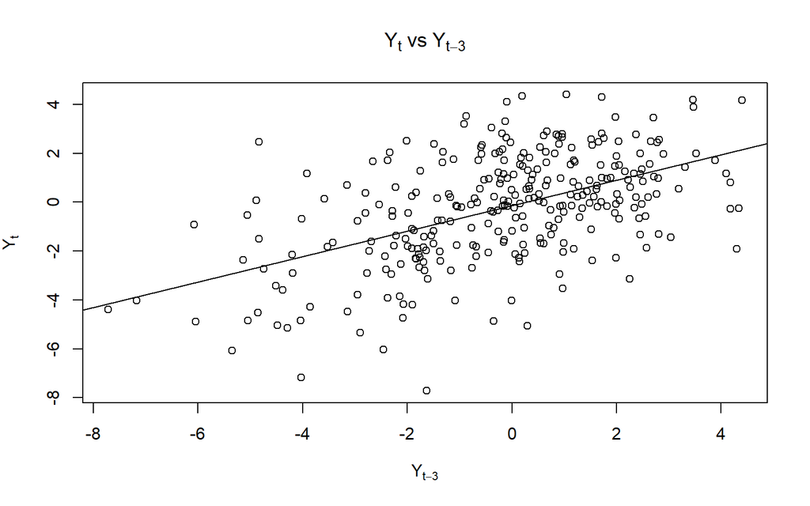

```r
plot(
  Y[-c(length(Y)-2,
       length(Y)-1,
       length(Y))],
  Y[-c(1,2,3)],
  main = expression(Y[t]~vs~Y[t-3]),
  xlab = expression(Y[t-3]),
  ylab = expression(Y[t])
)

abline(
  lm(
    Y[-c(1,2,3)] ~
      Y[-c(length(Y)-2,
            length(Y)-1,
            length(Y))]
  )
)
```

## Autokorelasi

```r
# Autokorelasi  empiris
cor_lag1 <- cor(
  arma22[-1],
  arma22[-length(arma22)]
)

cor_lag2 <- cor(
  arma22[-c(1,2)],
  arma22[-c(length(arma22)-1, length(arma22))]
)

cor_lag3 <- cor(
  arma22[-c(1,2,3)],
  arma22[-c(length(arma22)-2,
             length(arma22)-1,
             length(arma22))]
)

# Autokorelasi teoritis
teoritis <- ARMAacf(
  ar = c(0.5, 0.2),
  ma = c(0.4, 0.6),
  lag.max = 3
)
hasil_acf3 <- data.frame(
  Lag = 1:3,
  Empiris = c(cor_lag1, cor_lag2, cor_lag3),
  Teoritis = teoritis[2:4]
)

hasil_acf3
```

```
##   Lag   Empiris  Teoritis
## 1   1 0.8422126 0.8591993
## 2   2 0.7365114 0.7491908
## 3   3 0.5169990 0.5464353
```

Nilai empiris relatif mendekati nilai teoritis, meskipun terdapat perbedaan yang disebabkan oleh variasi sampel. Autokorelasi bernilai positif dan cenderung menurun seiring bertambahnya lag. Pola ini sesuai dengan karakteristik ARMA(2,2), di mana ACF umumnya menurun secara bertahap (tailing off) dan tidak langsung terputus setelah lag tertentu.

# Kesimpulan

Secara keseluruhan, MA(2), AR(2), dan ARMA(2,2) menunjukkan pola yang sesuai dengan karakteristik teoritis masing-masing model. Perbedaan antara autokorelasi empiris dan teoritis masih wajar karena adanya variasi sampel.